# 16S Data Analysis

Lan Huong Nguyen

Institute for Computational and Mathematical Engineering, Stanford University, CA 94305

18 July 2019

Edited July 15th, 2019

```r
pkgs_needed <- c("phyloseq", "tidyverse", "RColorBrewer", "DESeq2",
               "data.table", "readxl", "BiocManager", "decontam")
BiocManager::install(setdiff(pkgs_needed, installed.packages()))

library("RColorBrewer")
library("phyloseq")
library("tidyverse")

datadir <-"../../data/"# "/scratch/PI/sph/resilience/"
curdir <- getwd()
source('../utils.R')

theme_set(theme_bw())
theme_update(
  text = element_text(15),
  panel.border = element_rect(size = 0.5),
  panel.grid = element_blank(),
  axis.ticks = element_blank(),
  legend.title = element_text(size = 12),
  legend.text = element_text(size = 12),
  legend.position = "bottom",
  strip.background = element_blank()
)
```

# Sample Information

```r
# loading sample info
smpinfo_file <- file.path(
  datadir, "sample_info/Mapping_File_19Oct2018.xlsx")

# Measurement Information
meas <- readxl::read_xlsx(smpinfo_file, sheet = "Meas")
colnames(meas) <- meas[1, ]
meas <- meas[-1, ] %>%
  rename(Samp_ID = SampID) %>%
  select(Meas_ID:Meas_Type)
```

```r
# Sample Information
interv_levs <- c("NoInterv",
                 "PreDiet", "MidDiet", "PostDiet",
                 "PreCC", "MidCC", "PostCC",
                 "PreAbx", "MidAbx", "PostAbx", "UnpAbx")

samp <- readxl::read_xlsx(smpinfo_file, "Samp", skip = 1)  %>%
  mutate_at(
    .vars = c("Diet_Interval", "CC_Interval", "Abx_Interval"),
    .funs = function(x) {
      x <- ifelse(x == "Midabx","MidAbx", x)
      x <- ifelse(x == "NA", "NoInterv", x)
      x <- factor(x, interv_levs)
      return(x)
    }
  ) %>%
  mutate_at(
    .vars = vars(contains("Date")),
    .funs = function(x) {
      as.Date(as.numeric(x), origin="1899-12-30")
    }
  ) %>%
  mutate(
    Interval = paste0(Diet_Interval, "_", CC_Interval, "_", Abx_Interval),
    Interval = ifelse(grepl("MidAbx", Interval), "MidAbx", Interval),
    Interval = ifelse(grepl("MidDiet", Interval), "MidDiet", Interval),
    Interval = ifelse(grepl("MidCC", Interval), "MidCC", Interval),
    Interval = ifelse(!grepl("Post", Interval) & !grepl("Mid", Interval) &
                  !grepl("UnpAbx", Interval), "NoInterv", Interval),
    Interval = gsub("NoInterv_", "", Interval),
    Interval = gsub("_NoInterv", "", Interval),
    Interval = factor(Interval, unique(Interval))
  ) %>%
  mutate(
    Group = sapply(1:nrow(.), function(i) {
      group <- c()
      if(Diet_RelDay[i] != "NA") group <- c(group, "Diet")
      if(CC_RelDay[i] != "NA") group <- c(group, "CC")
      if(Abx_RelDay[i] != "NA") group <- c(group, "Abx")
      if(length(group) == 0) group <- "NoIntv"
      return(paste(group, collapse = "_"))
    })
  ) %>%
  select(Samp_ID:Abx_RelDay, Interval, Group)
head(samp)
```

```r
# Subject Data
subj_data <- readxl::read_xlsx(
  smpinfo_file, sheet = "Subj", skip = 1,
  col_types = c(rep("text", 5), rep("guess", 864))) %>%
  mutate_at(
    .vars = vars(contains("Date")),
    .funs = function(x) {
      as.Date(as.numeric(x), origin="1899-12-30")
    }
  ) %>%
  mutate(Age = `Age...9`) %>%
  dplyr::select(Subject, First_Sample_Date, CC_Date, Diet_StartDate,
         Abx_StartDate, Age, contains("Age..."), Gender:Blood_Pressure, Blood_Type, BirthYear)
subj_data <- subj_data[-1, ]
head(subj_data)
```

```r
meas_info <- meas %>%
  left_join(samp, by = c("Samp_ID")) %>%
  left_join(subj_data, by = "Subject") %>%
  mutate(Event_Code = ifelse(!is.na(Event_Code.x), Event_Code.x, Event_Code.y))
write.csv(meas_info, file.path(datadir, "sample_info/meas_info_15July2019.csv"))
```

```r
meas_info <- read.csv( file.path(datadir, "sample_info/meas_info_15July2019.csv"), row.names = 1) %>%
  mutate_at(.vars = vars(contains("Date")),
            .funs = function(x) {as.Date(as.character(x), "%Y-%m-%d")})
head(meas_info)
```

```r
start_dates <- meas_info %>%
   group_by(Subject, First_Sample_Date) %>%
    summarise(Real_First_Sample_Date = min(Samp_Date, na.rm = TRUE))
start_dates %>% filter(First_Sample_Date != Real_First_Sample_Date)
```

Fix one incorrect first sample date:

```r
meas_info <- meas_info %>%
  left_join(start_dates) %>%
  mutate(DaysFromStart = as.numeric(Samp_Date - Real_First_Sample_Date ))
write.csv(meas_info,  file.path(datadir, "sample_info/meas_info_15July2019.csv"))
```

```r
meas_info <- read.csv( file.path(datadir, "sample_info/meas_info_15July2019.csv"), row.names = 1)
smp_modality_count <- meas_info %>%
  select(Meas_ID, Samp_ID, Meas_Type) %>%
  group_by(Samp_ID) %>%
  summarise(
    modalities = paste0(unique(Meas_Type), collapse = "_"),
    modality_count = n()
  ) %>%
  mutate(
    modalities = ifelse(modalities == "MetaT_MetaG_16S",
                        "16S_MetaG_MetaT", modalities)
  )
```

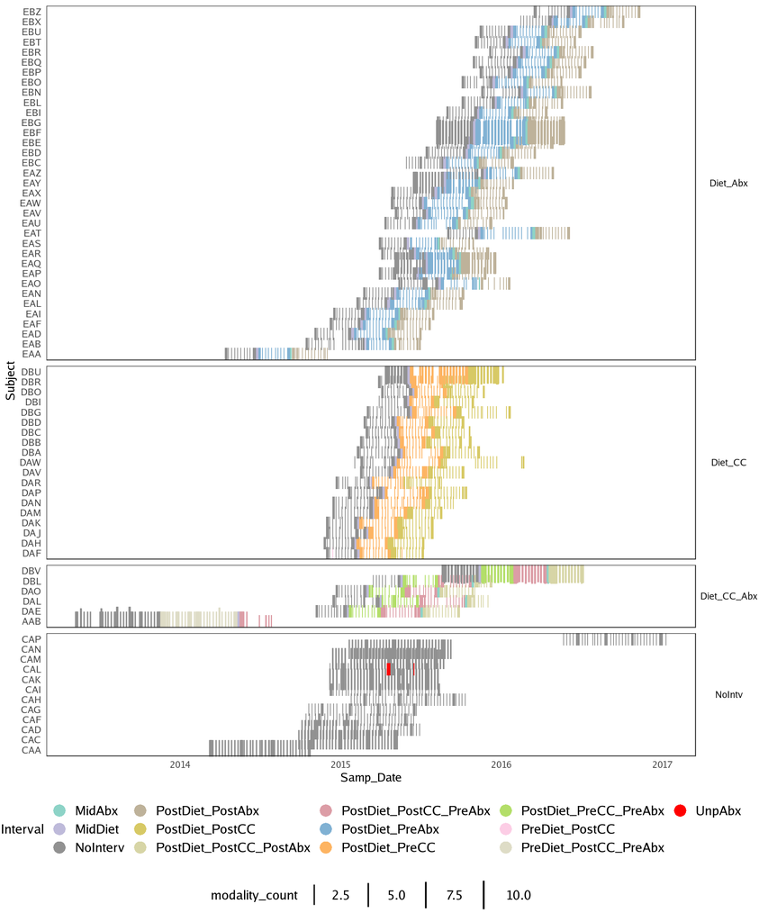

```r
df2plot <- meas_info %>%
  left_join(smp_modality_count) %>%
  select(Meas_ID, Samp_ID, Subject, Samp_Date, Meas_Type,
         Group, Interval, modalities, modality_count) %>%
  mutate(Samp_Date = as.Date(Samp_Date)) %>%
  filter(!grepl("NA", Subject))


new_intv_levs <- unique(meas_info$Interval)
colors <- colorRampPalette(brewer.pal(8, "Set3"))(length(new_intv_levs)-2)
colors <- c("grey57", "red", colors)
names(colors) <- c("NoInterv", "UnpAbx",
                   setdiff(new_intv_levs, c("NoInterv", "UnpAbx")))
ggplot(df2plot %>%
         filter(
           !(Group %in% c("Abx", "CC", "CC_Abx")),
           !is.na(Subject), !grepl("QC", Subject),
           !(Subject  %in% c("DAG", "DAC")))
       ) +
  geom_point(
      pch = 124,
      aes(y = Subject, x = Samp_Date, color = Interval,
          fill = Interval, size = modality_count)
    ) +
    facet_grid(Group ~ ., scales = "free", space = "free") +
    scale_color_manual(values = colors) +
    scale_size_continuous(range = c(5, 10)) +
    theme(legend.direction = "horizontal", legend.box = "vertical",
          strip.text.y = element_text(angle=0)) +
    guides(color = guide_legend(ncols = 4, override.aes = list(size=5, pch = 16)),
           size = guide_legend(override.aes = list(color="black")))
```

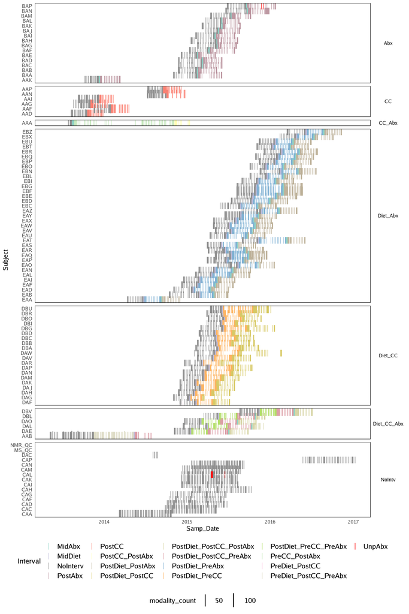

```r
ggplot(df2plot) +
  geom_point(
      pch = 124,
      aes(y = Subject, x = Samp_Date, color = Interval,
          fill = Interval, size = modality_count)
    ) +
    facet_grid(Group ~ ., scales = "free", space = "free") +
    scale_color_manual(values = colors) +
    scale_size_continuous(range = c(5, 10)) +
    theme(legend.direction = "horizontal", legend.box = "vertical",
          strip.text.y = element_text(angle=0)) +
    guides(color = guide_legend(override.aes = list(size=5)),
           size = guide_legend(override.aes = list(color="black")))
```

```r
rm("colors", "df2plot", "smp_modality_count", "new_intv_levs")
```

```r
levels <- unique(meas_info$Interval)
cols_itv <- c("grey77", colorRampPalette(brewer.pal(9, "Set1"))(length(levels) - 1))
names(cols_itv) <- c("NoInterv", setdiff(levels, "NoInterv"))
```

# Generate Phyloseq Object

First we need to generate a new phyloseq object with samples from two new batches.

We read the data stored as a `phyloseq` object from batches 1-4, then 5-6.

```r
# Bacthes 1-4
first_batches_dir <- file.path(datadir, "16S/16S_dada2_results/")

psRDP <- readRDS(file.path(first_batches_dir, "phyloseq_RDP.rds"))
psRDP

psRDPMult <- readRDS(file.path(first_batches_dir, "phyloseq_RDP_multispecies.rds"))
psRDPMult

psSilva <- readRDS(file.path(first_batches_dir, "phyloseq_Silva.rds"))
psSilva

psSilvaMult <- readRDS(file.path(first_batches_dir, "phyloseq_Silva_multispecies.rds"))
psSilvaMult
```

```r
# Bacthes 5-6
# Copied from curie server in folder:
# /relman02/data/relman/hmd/HMD_16S_V45/HMD_16S_5-6_annex/16S_5-6_DADA2_output/
second_batches_dir <- file.path(datadir, "16S/Les_Results/16S_5-6_DADA2_output")

psRDP2 <- readRDS(file.path(second_batches_dir, "phyloseq_RDP.rds"))
psRDP2

psRDPMult2 <- readRDS(file.path(second_batches_dir, "phyloseq_RDP_multispecies.rds"))
psRDPMult2

psSilva2 <- readRDS(file.path(second_batches_dir, "phyloseq_Silva.rds"))
psSilva2

psSilvaMult2 <- readRDS(file.path(second_batches_dir, "phyloseq_Silva_multispecies.rds"))
psSilvaMult2
```

```r
psRDP_merge <- merge_phyloseq(psRDP, psRDP2)
psRDPMult_merge <- merge_phyloseq(psRDPMult, psRDPMult2)
psSilva_merge <- merge_phyloseq(psSilva, psSilva2)
psSilvaMult_merge <- merge_phyloseq(psSilvaMult, psSilvaMult2)
rm(psRDP, psRDP2, psRDPMult, psRDPMult2, psSilva, psSilva2, psSilvaMult, psSilvaMult2)
```

```r
df <- bind_rows(
  data.frame(DB = "RDP", tax_table(psRDP_merge)@.Data),
  data.frame(DB = "Silva", tax_table(psSilva_merge)@.Data),
  data.frame(DB = "RDP_Mult", tax_table(psRDPMult_merge)@.Data),
  data.frame(DB = "Silva_Mult", tax_table(psSilvaMult_merge)@.Data)
)

# df %>%
#   group_by(DB) %>%
#   summarise_all(.funs = list(
#     function(x) sum(!is.na(x))
#   )
# )

# df %>%
#   group_by(DB) %>%
#   summarise_all(.funs = list(
#     function(x) round(100*sum(!is.na(x))/ntaxa(psRDP_merge), 1)
#   )
# )
```

```r
newTaxtab <- data.frame(as(tax_table(psRDP_merge), "matrix"))
newTaxtab <- cbind(newTaxtab, data.frame(SpeciesMult = as(tax_table(psRDPMult_merge), "matrix")[, "Species"]))
newTaxtab <- cbind(newTaxtab, data.frame(GenusSilva = as(tax_table(psSilva_merge), "matrix")[, "Genus"]))
newTaxtab <- cbind(newTaxtab, data.frame(SpeciesSilva = as(tax_table(psSilva_merge), "matrix")[, "Species"]))
newTaxtab <- cbind(
  newTaxtab, "SpeciesSilvaMult" = as(tax_table(psSilvaMult_merge), "matrix")[, "Species"])
newTaxtab <- cbind(newTaxtab, Seq = rownames(newTaxtab))
rownames(newTaxtab) <- paste0("Seq", 1:nrow(newTaxtab))

seqtab <- as(otu_table(psRDP_merge), "matrix")
seqtab <- seqtab[newTaxtab[, "Seq"], ]
rownames(seqtab) <- rownames(newTaxtab)
```

```r
ps_smp_names <- colnames(seqtab)
names(ps_smp_names) <- colnames(seqtab)

batch_info <- gsub("HMD_", "", ps_smp_names)
batch_info <- gsub("\\_(.*)", "", batch_info)

ps_smp_names <- gsub("\\-(.*)", "", ps_smp_names)
ps_smp_names <- gsub("(.*)\\_M", "M", ps_smp_names)
head(ps_smp_names)
tail(ps_smp_names)
length(ps_smp_names) == length(unique(ps_smp_names))
```

```r
all(ps_smp_names %in% meas_info$Meas_ID)
```

```r
ps_smp_names[which(!ps_smp_names %in% meas_info$Meas_ID)]
# "HMD_16S5_SplitLib_Unassigned"
```

```r
keep_smp_names <- ps_smp_names[which(ps_smp_names %in% meas_info$Meas_ID)]
batch_info <- batch_info[which(ps_smp_names %in% meas_info$Meas_ID)]
names(batch_info) <- keep_smp_names
seqtab <- seqtab[, names(keep_smp_names)]
colnames(seqtab) <- keep_smp_names
```

We extract the information for the obtained samples:

```r
samp_16S <- meas_info %>%
  filter(Meas_ID %in% keep_smp_names) %>%
  left_join(data.frame(Meas_ID = names(batch_info),
                       Sequencing_Run = batch_info))
rownames(samp_16S) <- samp_16S$Meas_ID
head(samp_16S)
```

```r
ps_combined <- phyloseq(
  otu_table(seqtab, taxa_are_rows = TRUE),
  sample_data(samp_16S),
  tax_table(as(newTaxtab, "matrix")))
ps_combined
```

```r
physeqfile <- file.path(datadir, "16S/phyloseq/perturb_physeq_15Jul19.rds")
saveRDS(ps_combined, file = physeqfile)
# otu_table()   OTU Table:         [ 19638 taxa and 4561 samples ]
# sample_data() Sample Data:       [ 4561 samples by 39 sample variables ]
```

# Preprocess Data

```r
physeqfile <- file.path(datadir, "16S/phyloseq/perturb_physeq_15Jul19.rds")
ps0 <- readRDS(file = physeqfile)
SMP <- data.frame(ps0@sam_data, stringsAsFactors = FALSE) %>%
  mutate(SampleDepth = sample_sums(ps0))
ps0

# otu_table()   OTU Table:         [ 19638 taxa and 4561 samples ]
# sample_data() Sample Data:       [ 4561 samples by 39 sample variables ]
# tax_table()   Taxonomy Table:    [ 19638 taxa by 12 taxonomic ranks ]
```

We will now remove samples from subject who did not have sufficient number of samples sequenced, either because they came from a different experiment or because the subjects did not complete the study.

```r
freq <- table(ps0@sam_data$Subject)
remove_subjects <- names(freq)[freq < 10] # "AAA" "AAB" "AAN" "DAC" "DAG"
remove_subjects
ps <- subset_samples(ps0, !Subject %in% remove_subjects)
ps
# otu_table()   OTU Table:         [ 19638 taxa and 4521 samples ]
```

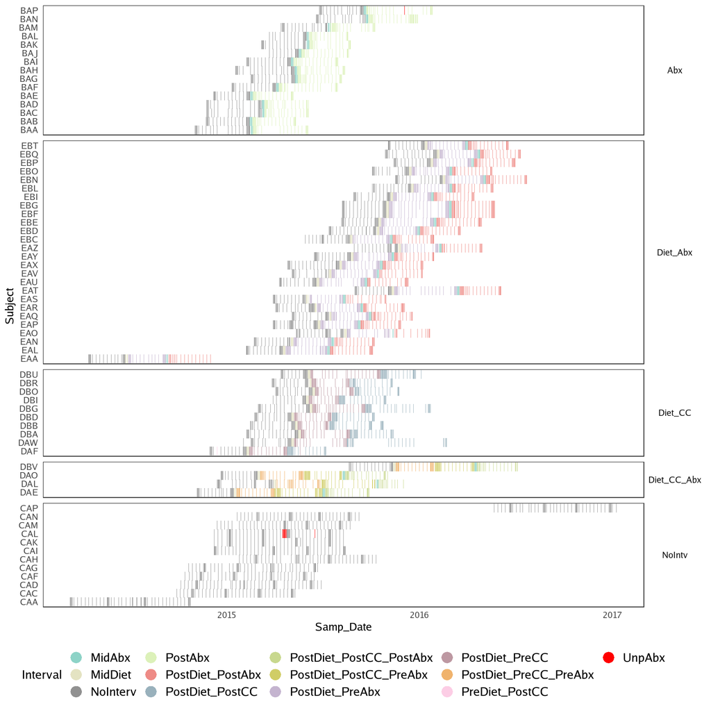

```r
df2plot <- data.frame(sample_data(psSubj)) %>%
  select(Meas_ID, Samp_ID, Subject, Samp_Date, Meas_Type,
         Group, Interval) %>%
  mutate(Samp_Date = as.Date(Samp_Date))


new_intv_levs <- unique(df2plot$Interval)
colors <- colorRampPalette(brewer.pal(8, "Set3"))(length(new_intv_levs)-2)
colors <- c("grey57", "red", colors)
names(colors) <- c("NoInterv", "UnpAbx",
                   setdiff(new_intv_levs, c("NoInterv", "UnpAbx")))
df2plot %>%
  ggplot() +
  geom_point(
      pch = 124, size = 3,
      aes(y = Subject, x = Samp_Date, color = Interval,
          fill = Interval)
    ) +
    facet_grid(Group ~ ., scales = "free", space = "free") +
    scale_color_manual(values = colors) +
    theme(legend.direction = "horizontal", legend.box = "vertical",
          strip.text.y = element_text(angle=0)) +
    guides(color = guide_legend(ncols = 4, override.aes = list(size=5, pch = 16)),
           size = guide_legend(override.aes = list(color="black")))
```

## Filter taxa

Next, we will filter out taxa which are not present in samples of at least two different subjects.

```r
minTaxaSubjPrev <- 2
minNonZeroSamples <- 5
minPrevLevel <- 5

# Compute prevalence across subjects
num_subj_present <- function(physeq, subject_indicator = "Subject") {
  smp <- data.frame(physeq@sam_data, stringsAsFactors = FALSE)
  seqtab <- as(otu_table(physeq), "matrix")
  if(!taxa_are_rows(physeq)) seqtab <- t(seqtab)
  sapply(1:ntaxa(physeq), function(i) {
    subj.present <- smp[[subject_indicator]][seqtab[i, ] >= minPrevLevel]
    freq <- table(subj.present)
    sum(freq >= minNonZeroSamples)
    #length(unique(subj.present))aDAMAD
  })
}
subjects_prevalence <- num_subj_present(ps)

# Filter taxa present in more than 1 subject
ps <- subset_taxa(ps, subjects_prevalence >= minTaxaSubjPrev)
ps
#otu_table()   OTU Table:         [ 2438 taxa and 4521 samples ]
```

```r
ps <- subset_samples(ps, sample_sums(ps) > 0)
ps
#otu_table()   OTU Table:         [ 2438 taxa and 4500 samples ]
saveRDS(ps, file = file.path(datadir, "16S/phyloseq/perturb_physeq_fltr2438_15Jul19.rds"))
```

## Estimate the phylo tree

Go to code in “/scratch/users/lanhuong/Projects/perturbation_16s/16S/construct_phylo_tree.R” and see how the tree was estimated.

```r
ps <- readRDS(file.path(datadir, "16S/phyloseq/perturb_physeq_fltr2438_15Jul19.rds"))
ps
# otu_table()   OTU Table:         [ 2438 taxa and 4500 samples ]
load(file.path(datadir, "16S/phyloseq/phylo_fit_fltr2438_15Jul19.rda"))
phy_tree(ps) <- rootedGTRtree
ps
saveRDS(ps, file = file.path(datadir, "16S/phyloseq/perturb_physeq_fltr2438_15Jul19.rds"))
```

```r
# Assign colors to taxa
tax_rank <- "Family"
n_taxa <- 15

taxTab <- data.frame(as(tax_table(ps), "matrix"))

taxFreq <- data.frame(Seq_ID = taxa_names(ps), Seq_Sum = taxa_sums(ps)) %>%
  left_join(taxTab %>%
              rownames_to_column("Seq_ID")) %>%
  group_by_(tax_rank) %>%
  summarise(Taxa_Sum = sum(Seq_Sum)) %>%
  filter(!is.na(.[[tax_rank]])) %>%
  arrange(desc(Taxa_Sum)) %>%
  top_n(n_taxa) %>%
  mutate(color = colorRampPalette(brewer.pal(8, "Dark2"))(n_taxa))

other <-  data.frame("Other", 0, "grey77")
colnames(other) <- colnames(taxFreq)
taxFreq <- rbind(taxFreq, other)

taxa_col <- tibble(
  Seq_ID = taxa_names(ps),
  Taxa = c(tax_table(ps)[, tax_rank])) %>%
  mutate(
    Taxa = ifelse(is.na(Taxa), "Unknown", Taxa),
    Taxa = ifelse(Taxa == "", "Unknown", Taxa),
    Taxa = ifelse(Taxa %in% taxFreq[[tax_rank]], Taxa, "Other")) %>%
  left_join(taxFreq, by=c("Taxa" = tax_rank))
```

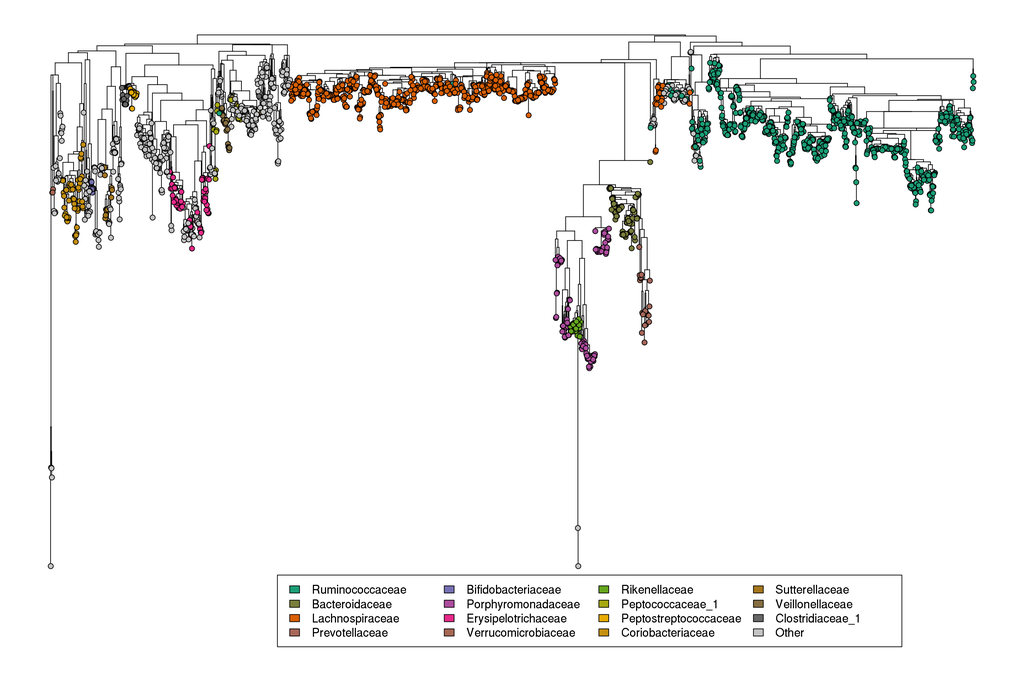

```r
default_par <- par()
par(mar=c(7,1,1,1), xpd = TRUE)
plot(ps@phy_tree, label.offset=0.7, show.tip.label = FALSE,
     direction = "downwards")
par(mar=c(1,1,1,1), xpd = TRUE)
ape::tiplabels(pch=21, col="black", adj=1, bg=taxa_col$color, cex=1)
legend(x= 600, y = -0.1, legend = taxFreq[[tax_rank]],
       fill = taxFreq$color, ncol = 4, cex = 1.2)
```

## Decontamination

Remove contamination:

```r
# devtools::install_github("benjjneb/decontam")
library(decontam); packageVersion("decontam")
```

```
## [1] '1.2.1'
```

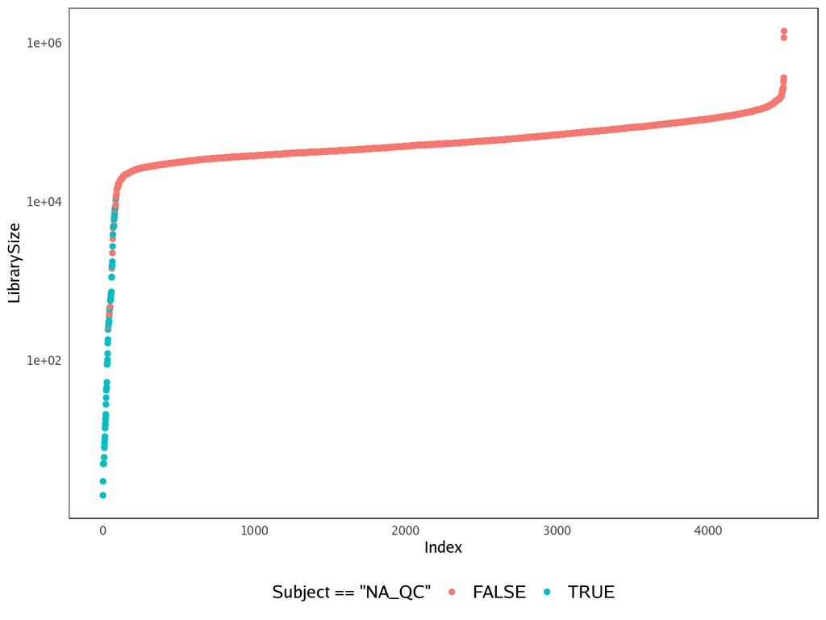

```r
df <- data.frame(sample_data(ps)) # Put sample_data into a ggplot-friendly data.frame
df$LibrarySize <- sample_sums(ps)
df <- df[order(df$LibrarySize),]
df$Index <- seq(nrow(df))
ggplot(data=df, aes(x=Index, y=LibrarySize, color=Subject == "NA_QC")) +
  geom_point() +
  scale_y_log10()
```

```r
table(df$Subject)
```

```
##
##   BAA   BAB   BAC   BAD   BAE   BAF   BAG   BAH   BAI   BAJ   BAK   BAL   BAM   BAN   BAP   CAA   CAC   CAD   CAF   CAG   CAH   CAI   CAK   CAL   CAM   CAN   CAP   DAE   DAF   DAL   DAO   DAW   DBA
##    49    51    46    48    48    52    51    54    51    42    45    42    49    59    51    52    50    52    49    48    52    52    52    61    48    50    50   106    71    92   102    65    78
##   DBB   DBD   DBG   DBI   DBO   DBR   DBU   DBV   EAA   EAL   EAN   EAO   EAP   EAQ   EAR   EAS   EAT   EAU   EAV   EAX   EAY   EAZ   EBC   EBD   EBE   EBF   EBG   EBI   EBL   EBN   EBO   EBP   EBQ
##    76    72    86    65    69    65    78    98    62    80    71    67    85    71    77    58    79    72    65    79    77    70    75    76    80    84    85    75    74    75    74    76    77
##   EBT NA_QC
##    75    84
```

```r
df %>% filter(Subject == "NA_QC") %>%
  .[["Event_Code"]] %>% as.character
```

```
##  [1] "PL16_B1" "PL55_B2" "PL10_B1" "PL28_B2" "PCR_B1"  "PL37_B1" "PL54_B1" "PCR_B3"  "PL30_B1" "PL41_B1" "PL10_B2" "PL52_B2" "PL15_B2" "PL29_B1" "PL32_B1" "PL44_B2" "PL14_B2" "PL48_B1" "PL31_B1"
## [20] "PL46_B2" "PL33_B1" "PL48_B2" "PL38_B2" "PL37_B1" "PL29_B2" "PL12_B3" "PL53_B1" "PL26_B1" "PL45_B2" "PL26_B2" "PL27_B2" "PL25_B2" "PL17_B1" "PL40_B1" "PL53_B2" "PL17_B2" "PL55_B1" "PL25_B1"
## [39] "PL50_B2" "PL57_B2" "PL45_B1" "PL40_B2" "PL34_B2" "PL54_B2" "PL27_B1" "PL35_B2" "PL33_B2" "PL21_B1" "PL43_B2" "PL18_B2" "PL16_B2" "PL36_B1" "PL15_B3" "PL39_B1" "PL41_B2" "PL11_B2" "PL24_B1"
## [58] "PL14_B1" "PL15_B1" "PL22_B1" "PL42_B1" "PL20_B2" "PL19_B1" "PL23_B1" "PL20_B1" "PL51_B2" "PL24_B2" "PL52_B1" "PL19_B2" "PL22_B2" "PL32_B2" "PL42_B1" "PL36_B2" "PL56_B2" "PL43_B1" "PL18_B1"
## [77] "PL49_B1" "PL11_B1" "PL50_B1" "PL46_B1" "PL12_B2" "PL51_B1" "PL13_B1" "PL44_B1"
```

```r
df %>% filter(Subject == "NA_QC") %>% .[["Samp_Type"]] %>% table()
```

```
## .
##    ExtrCont ExtrControl
##          57          27
```

```r
sample_data(ps)$neg_control <- (sample_data(ps)$Samp_Type == "ExtrControl" | sample_data(ps)$Samp_Type == "ExtrCont")
df$neg_control <- df$Samp_Type == "ExtrControl" | df$Samp_Type == "ExtrCont"
```

```r
df %>% filter(!neg_control) %>%
  .[["LibrarySize"]] %>% summary()
```

```
##    Min. 1st Qu.  Median    Mean 3rd Qu.    Max.
##       6   39970   54250   65937   81931 1413362
```

```r
df %>% filter(neg_control) %>%
  .[["LibrarySize"]] %>% summary()
```

```
##    Min. 1st Qu.  Median    Mean 3rd Qu.    Max.
##       2      40     461   11218    5290  120786
```

```r
contamdf.prev <- isContaminant(ps, method="prevalence", neg="neg_control")
table(contamdf.prev$contaminant)
```

```
##
## FALSE  TRUE
##  2425    13
```

```r
# contaminants
tax_table(ps)[which(contamdf.prev$contaminant), 2:7]
```

```
## Taxonomy Table:     [13 taxa by 6 taxonomic ranks]:
##         Phylum           Class                 Order                Family                Genus                  Species
## Seq55   "Bacteroidetes"  "Bacteroidia"         "Bacteroidales"      "Prevotellaceae"      "Prevotella"           NA
## Seq77   "Bacteroidetes"  "Bacteroidia"         "Bacteroidales"      "Bacteroidaceae"      "Bacteroides"          "plebeius"
## Seq82   "Proteobacteria" "Gammaproteobacteria" "Aeromonadales"      "Succinivibrionaceae" "Succinivibrio"        NA
## Seq86   "Firmicutes"     "Erysipelotrichia"    "Erysipelotrichales" "Erysipelotrichaceae" "Holdemanella"         NA
## Seq157  "Bacteroidetes"  "Bacteroidia"         "Bacteroidales"      "Porphyromonadaceae"  NA                     NA
## Seq172  "Bacteroidetes"  "Bacteroidia"         "Bacteroidales"      "Porphyromonadaceae"  NA                     NA
## Seq264  "Proteobacteria" "Alphaproteobacteria" NA                   NA                    NA                     NA
## Seq353  "Bacteroidetes"  "Bacteroidia"         "Bacteroidales"      NA                    NA                     NA
## Seq361  "Bacteroidetes"  "Bacteroidia"         "Bacteroidales"      "Porphyromonadaceae"  "Odoribacter"          "laneus"
## Seq371  "Firmicutes"     NA                    NA                   NA                    NA                     NA
## Seq532  "Firmicutes"     "Erysipelotrichia"    "Erysipelotrichales" "Erysipelotrichaceae" NA                     NA
## Seq2810 "Firmicutes"     NA                    NA                   NA                    NA                     NA
## Seq5626 "Firmicutes"     "Clostridia"          "Clostridiales"      "Ruminococcaceae"     "Pseudoflavonifractor" NA
```

```r
contamdf.prev05 <- isContaminant(
  ps, method="prevalence", neg="neg_control", threshold=0.5)
table(contamdf.prev05$contaminant)
```

```
##
## FALSE  TRUE
##  2279   159
```

```r
# contaminants
tax_table(ps)[which(contamdf.prev05$contaminant)[1:10], 2:7]
```

```
## Taxonomy Table:     [10 taxa by 6 taxonomic ranks]:
##        Phylum           Class                 Order                Family                Genus             Species
## Seq10  "Bacteroidetes"  "Bacteroidia"         "Bacteroidales"      "Prevotellaceae"      "Prevotella"      NA
## Seq44  "Firmicutes"     "Erysipelotrichia"    "Erysipelotrichales" "Erysipelotrichaceae" "Catenibacterium" "mitsuokai"
## Seq55  "Bacteroidetes"  "Bacteroidia"         "Bacteroidales"      "Prevotellaceae"      "Prevotella"      NA
## Seq77  "Bacteroidetes"  "Bacteroidia"         "Bacteroidales"      "Bacteroidaceae"      "Bacteroides"     "plebeius"
## Seq82  "Proteobacteria" "Gammaproteobacteria" "Aeromonadales"      "Succinivibrionaceae" "Succinivibrio"   NA
## Seq86  "Firmicutes"     "Erysipelotrichia"    "Erysipelotrichales" "Erysipelotrichaceae" "Holdemanella"    NA
## Seq113 "Bacteroidetes"  "Bacteroidia"         "Bacteroidales"      "Prevotellaceae"      "Prevotella"      NA
## Seq157 "Bacteroidetes"  "Bacteroidia"         "Bacteroidales"      "Porphyromonadaceae"  NA                NA
## Seq172 "Bacteroidetes"  "Bacteroidia"         "Bacteroidales"      "Porphyromonadaceae"  NA                NA
## Seq194 "Proteobacteria" "Alphaproteobacteria" "Rhodospirillales"   "Rhodospirillaceae"   "Aestuariispira"  NA
```

```r
psFamily <- tax_glom(ps, taxrank = "Family")
family_sum <- taxa_sums(psFamily)
topFamily <- as(psFamily@tax_table, "matrix")[order(-family_sum)[1:10], "Family"]
saveRDS(psFamily, file = "output/perturb_physeq_glom_family_15Jul19.rds")
```

```r
psFamily <- readRDS(file = "output/perturb_physeq_glom_family_15Jul19.rds")
family_sum <- taxa_sums(psFamily)
topFamily <- as(psFamily@tax_table, "matrix")[order(-family_sum)[1:10], "Family"]
```

```r
ps.pa <- transform_sample_counts(ps, function(abund) 1*(abund>0))
ps.pa.neg <- subset_samples(ps.pa, sample_data(ps.pa)$neg_control)
ps.pa.pos <- subset_samples(ps.pa, !sample_data(ps.pa)$neg_control)
ps.pa.pos.mid <- subset_samples(
  ps.pa.pos, (Diet_Interval == "MidDiet" | Abx_Interval == "MidAbx" | CC_RelDay %in% seq(1, 5)))

# Make data.frame of prevalence in positive and negative samples
df.pa <- data.frame(
  taxa.sum = taxa_sums(ps),
  pa.pos=taxa_sums(ps.pa.pos), pa.neg=taxa_sums(ps.pa.neg),
  contaminant=contamdf.prev$contaminant)

df.pa.mid <- data.frame(
  taxa.sum = taxa_sums(ps),
  pa.pos=taxa_sums(ps.pa.pos.mid),
  pa.neg=taxa_sums(ps.pa.neg),
  contaminant=contamdf.prev$contaminant)
```

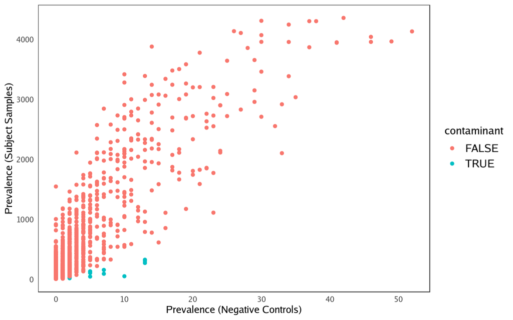

```r
ggplot(data=df.pa, aes(x=pa.neg, y=pa.pos, color=contaminant)) + geom_point() +
  xlab("Prevalence (Negative Controls)") + ylab("Prevalence (Subject Samples)") +
  theme(legend.position = "right")
```

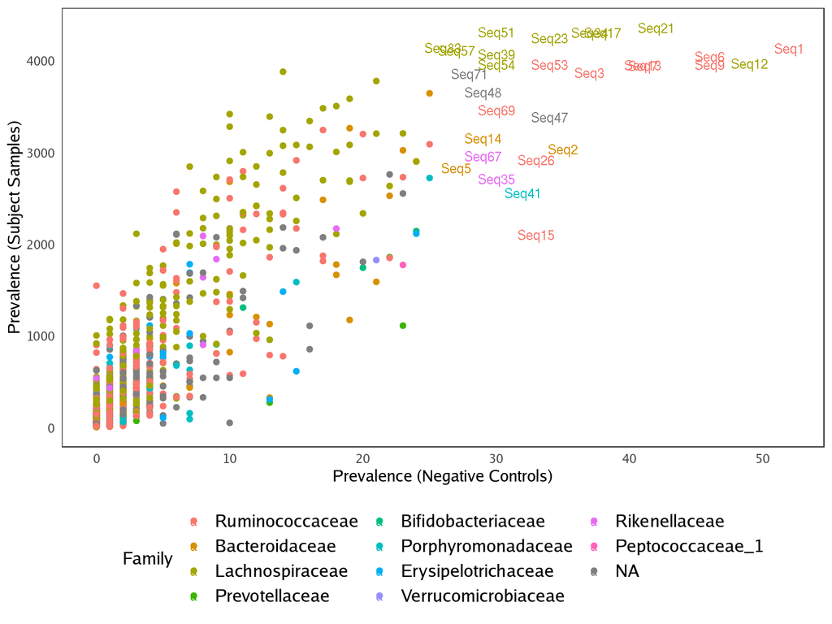

```r
df.pa <- df.pa %>%
  rownames_to_column("SeqID") %>%
  mutate(
    Family = factor(as(tax_table(ps.pa.pos), "matrix")[, "Family"], levels = topFamily)
  )

df.pa %>%
ggplot(aes(x=pa.neg, y=pa.pos, color=Family)) +
  geom_point(data = df.pa %>%  filter(pa.neg <= 25)) +
  geom_text(data = df.pa %>%  filter(pa.neg > 25), aes(label = SeqID)) +
  xlab("Prevalence (Negative Controls)") + ylab("Prevalence (Subject Samples)") +
  theme(legend.position = "right") + theme(legend.position = "bottom") +
  guides(color=guide_legend(ncol=3))
```

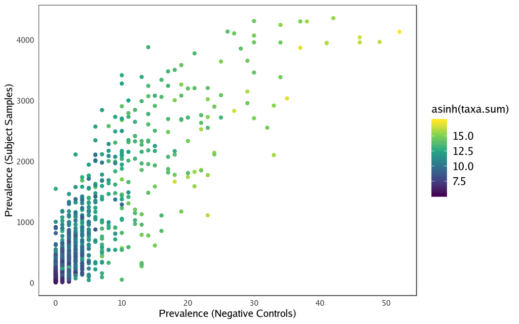

```r
ggplot(data=df.pa, aes(x=pa.neg, y=pa.pos, color=asinh(taxa.sum))) + geom_point() +
  xlab("Prevalence (Negative Controls)") + ylab("Prevalence (Subject Samples)") +
  scale_color_viridis_c() + theme(legend.position = "right")
```

```r
cross_contam_seqs <- df.pa %>% filter(pa.neg > 25) %>% .[["SeqID"]]
knitr::kable(tax_table(ps)[cross_contam_seqs, 5:7])
```

|  | Family | Genus | Species |
| --- | --- | --- | --- |
| Seq1 | Ruminococcaceae | Faecalibacterium | prausnitzii |
| Seq2 | Bacteroidaceae | Bacteroides | vulgatus |
| Seq3 | Ruminococcaceae | Faecalibacterium | prausnitzii |
| Seq5 | Bacteroidaceae | Bacteroides | vulgatus |
| Seq6 | Ruminococcaceae | Faecalibacterium | prausnitzii |
| Seq7 | Ruminococcaceae | Faecalibacterium | prausnitzii |
| Seq9 | Ruminococcaceae | Gemmiger | formicilis |
| Seq12 | Lachnospiraceae | NA | NA |
| Seq13 | Ruminococcaceae | Gemmiger | NA |
| Seq14 | Bacteroidaceae | Bacteroides | uniformis |
| Seq15 | Ruminococcaceae | Ruminococcus | bromii |
| Seq17 | Lachnospiraceae | Fusicatenibacter | saccharivorans |
| Seq21 | Lachnospiraceae | Blautia | obeum |
| Seq23 | Lachnospiraceae | Blautia | NA |
| Seq26 | Ruminococcaceae | Ruminococcus | bicirculans |
| Seq34 | Lachnospiraceae | Anaerostipes | hadrus |
| Seq35 | Rikenellaceae | Alistipes | putredinis |
| Seq39 | Lachnospiraceae | Dorea | longicatena |
| Seq41 | Porphyromonadaceae | Parabacteroides | merdae |
| Seq47 | Coriobacteriaceae | Collinsella | aerofaciens |
| Seq48 | Peptostreptococcaceae | Romboutsia | NA |
| Seq51 | Lachnospiraceae | Blautia | faecis |
| Seq53 | Ruminococcaceae | NA | NA |
| Seq54 | Lachnospiraceae | Blautia | NA |
| Seq57 | Lachnospiraceae | Coprococcus | comes |
| Seq67 | Rikenellaceae | Alistipes | NA |
| Seq69 | Ruminococcaceae | Butyricicoccus | NA |
| Seq71 | Streptococcaceae | Streptococcus | NA |
| Seq83 | Lachnospiraceae | Dorea | formicigenerans |

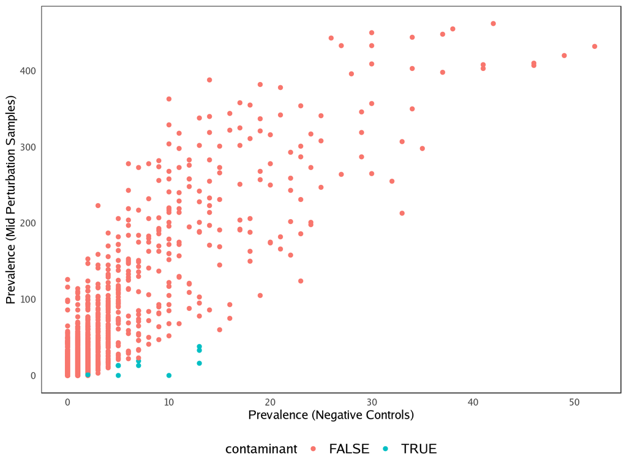

```r
ggplot(data=df.pa.mid, aes(x=pa.neg, y=pa.pos, color=contaminant)) + geom_point() +
  xlab("Prevalence (Negative Controls)") + ylab("Prevalence (Mid Perturbation Samples)")
```

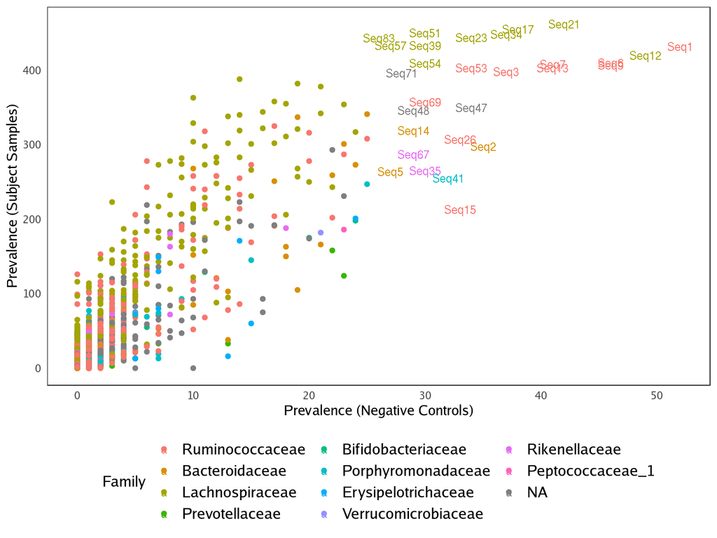

```r
df.pa.mid <- df.pa.mid %>%
  rownames_to_column("SeqID") %>%
  mutate(
    Family = factor(as(tax_table(ps.pa.pos.mid), "matrix")[, "Family"], levels = topFamily)
  )

df.pa.mid %>%
ggplot(aes(x=pa.neg, y=pa.pos, color=Family)) +
  geom_point(data = df.pa.mid %>%  filter(pa.neg <= 25)) +
  geom_text(data = df.pa.mid %>%  filter(pa.neg > 25), aes(label = SeqID)) +
  xlab("Prevalence (Negative Controls)") + ylab("Prevalence (Subject Samples)") +
  theme(legend.position = "right") + theme(legend.position = "bottom") +
  guides(color=guide_legend(ncol=3))
```

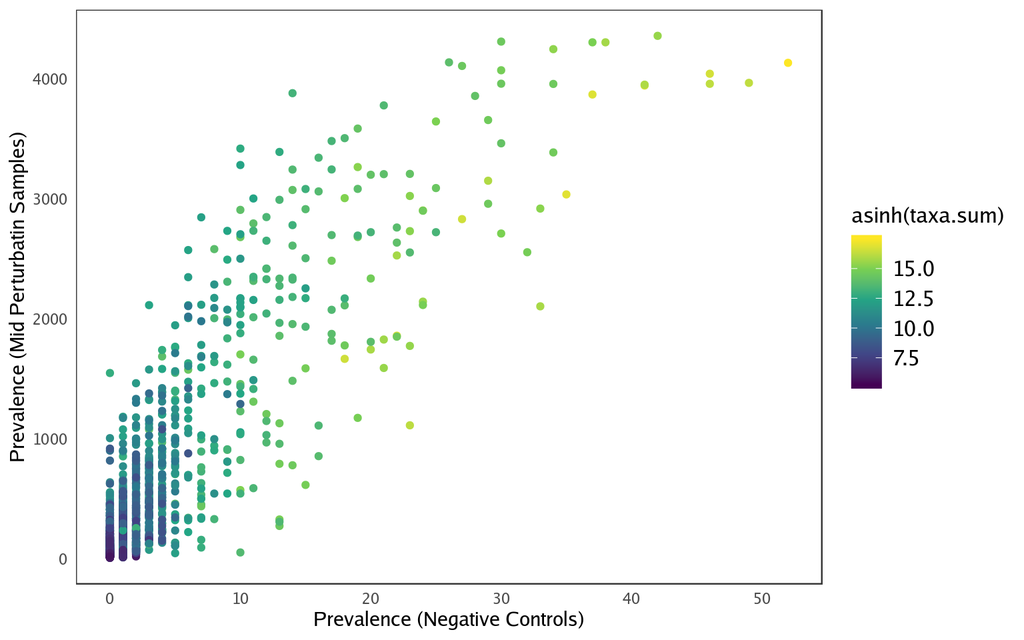

```r
ggplot(data=df.pa, aes(x=pa.neg, y=pa.pos, color=asinh(taxa.sum))) + geom_point() +
  xlab("Prevalence (Negative Controls)") + ylab("Prevalence (Mid Perturbatin Samples)") +
  scale_color_viridis_c() + theme(legend.position = "right")
```

```r
cross_contam_seqs_mid_perturb <- df.pa.mid %>%
  filter(pa.neg > 25, pa.pos > 300) %>% .[["SeqID"]]
knitr::kable(tax_table(ps)[cross_contam_seqs_mid_perturb, 5:7])
```

|  | Family | Genus | Species |
| --- | --- | --- | --- |
| Seq1 | Ruminococcaceae | Faecalibacterium | prausnitzii |
| Seq3 | Ruminococcaceae | Faecalibacterium | prausnitzii |
| Seq6 | Ruminococcaceae | Faecalibacterium | prausnitzii |
| Seq7 | Ruminococcaceae | Faecalibacterium | prausnitzii |
| Seq9 | Ruminococcaceae | Gemmiger | formicilis |
| Seq12 | Lachnospiraceae | NA | NA |
| Seq13 | Ruminococcaceae | Gemmiger | NA |
| Seq14 | Bacteroidaceae | Bacteroides | uniformis |
| Seq17 | Lachnospiraceae | Fusicatenibacter | saccharivorans |
| Seq21 | Lachnospiraceae | Blautia | obeum |
| Seq23 | Lachnospiraceae | Blautia | NA |
| Seq26 | Ruminococcaceae | Ruminococcus | bicirculans |
| Seq34 | Lachnospiraceae | Anaerostipes | hadrus |
| Seq39 | Lachnospiraceae | Dorea | longicatena |
| Seq47 | Coriobacteriaceae | Collinsella | aerofaciens |
| Seq48 | Peptostreptococcaceae | Romboutsia | NA |
| Seq51 | Lachnospiraceae | Blautia | faecis |
| Seq53 | Ruminococcaceae | NA | NA |
| Seq54 | Lachnospiraceae | Blautia | NA |
| Seq57 | Lachnospiraceae | Coprococcus | comes |
| Seq69 | Ruminococcaceae | Butyricicoccus | NA |
| Seq71 | Streptococcaceae | Streptococcus | NA |
| Seq83 | Lachnospiraceae | Dorea | formicigenerans |

```r
contaminant_seqs <- rownames(contamdf.prev[contamdf.prev$contaminant, ])
ps <- subset_taxa(ps, !taxa_names(ps) %in% contaminant_seqs)
saveRDS(ps, file = file.path(datadir, "16S/phyloseq/perturb_physeq_decontam_15Jul19.rds"))

save(list=c("cross_contam_seqs_mid_perturb", "cross_contam_seqs", "contamdf.prev", "contamdf.prev05"),
     file = "output/potential_cross_contam.rda")
```

## Filter samples

We then separate the subject data and the negative controls:

```r
psControls <- subset_samples(ps, Subject == "NA_QC")
psControls
# otu_table()   OTU Table:         [ 2425 taxa and 84 samples ]
```

```r
psSubj <- subset_samples(ps, Subject != "NA_QC")
psSubj
# otu_table()   OTU Table:         [ 2425 taxa and 4416 samples ]

minSampleSum <- 1e4
psSubj <- subset_samples(psSubj, sample_sums(psSubj) > minSampleSum)
psSubj
# otu_table()   OTU Table:         [ 2425 taxa and 4402 samples ]
```

```r
saveRDS(psControls, file = file.path(datadir, "16S/phyloseq/perturb_physeq_controls_decontam_15Jul19.rds"))
saveRDS(psSubj, file = file.path(datadir, "16S/phyloseq/perturb_physeq_participants_decontam_15Jul19.rds"))
```

## Variance Stabilization

```r
# Transform counts to not "over-weight" highly abundant taxa
#ps_asinh <- transform_sample_counts(ps, function(x) {asinh(x)})
```

```r
# Takes too long
dds <- phyloseq_to_deseq2(ps, design = ~ 1)
dds <- estimateSizeFactors(dds, type = "poscounts")
norm_counts <- counts(dds, normalized = TRUE)

# ## The following takes too long; and vst() does not work with too few genes with rowmeans > 5
# vsd <- varianceStabilizingTransformation(dds)
# ps_vst <- ps
# otu_table(ps_vst) <- otu_table(assay(vsd), taxa_are_rows = TRUE)
# save(list = c("ps", "pscontrols", "ps_asinh", "SMP", "SUBJ", "dds",
#               "norm_counts", "ps_vst", "vsd"),
#      file = processed_datafile)
```

# Distance Matrices

```r
SMP <- data.frame(psSubj@sam_data, stringsAsFactors = FALSE) %>%
  mutate(SampleDepth = sample_sums(psSubj))

SUBJ <-  SMP %>%
  select(Subject, Group, Age:BMI) %>%
  distinct()
```

```r
# takes a while
brayD.ihs <- phyloseq::distance(
    transform_sample_counts(psSubj, function(x) {asinh(x)}),
    method = "bray")
save(list = c("brayD.ihs"), file = "output/pairwise_dist_subj_16S.rda")
```

```r
jaccardD <- phyloseq::distance(
    psSubj, method = "jaccard", binary = TRUE)
save(list = c("brayD.ihs", "jaccardD"), file = "output/pairwise_dist_subj_16S.rda")
```

```r
study_arms <- as.character(unique(psSubj@sam_data$Group))

uniFracD.lst <- list()
study_arms <- setdiff(study_arms, names(uniFracD.lst))
for(gr in study_arms) {
  ps.gr <- phyloseq::subset_samples(psSubj, Group == gr)
  print(ps.gr)
  uniFracD.lst[[gr]] <- phyloseq::distance(
    ps.gr, method = "unifrac", parallel = TRUE,
    fast = TRUE, normalized = TRUE, weighted = FALSE)
  save(list = c("brayD.ihs", "jaccardD", "uniFracD.lst"),
       file = "../analysis/analysis_summer2019/output/pairwise_dist_subj_16S.rda")
}

save(list = c("brayD.ihs", "jaccardD", "uniFracD.lst"),
     file = "../analysis/analysis_summer2019/output/pairwise_dist_subj_16S.rda")
```

Process distance matrices

```r
distMat_to_2long <- function(distMat, sample_info = NULL,
                             cols_to_keep = NULL,
                             sample_id = "Meas_ID",
                             keep_only_same_subj = TRUE) {
  dist.df <- reshape2::melt(
    as.matrix(distMat),
    varnames = c("Sample_1", "Sample_2"),
    value.name = "dist") %>%
    mutate(Sample_1 = as.character(Sample_1),
           Sample_2 = as.character(Sample_2))
  if(!is.null(sample_info) & sample_id %in% colnames(sample_info)) {
    vars <- c(sample_id)
    names(vars) <- "Meas_ID"
    if(!is.null(cols_to_keep)) {
      vars <- c(vars, cols_to_keep)
      names(vars) <- c("Meas_ID", cols_to_keep)
    }
    dist.df <- dist.df %>%
      left_join(
        sample_info %>% select(!!vars),
        by = c("Sample_1" = "Meas_ID"))

    dist.df <- dist.df %>%
      left_join(
        sample_info %>% select(!!vars),
        by = c("Sample_2" = "Meas_ID"),
        suffix = c("_1", "_2"))

    if(keep_only_same_subj) {
      dist.df <- dist.df %>%
        filter(Subject_1 == Subject_2) %>%
        rename(Subject = Subject_1) %>%
        select(-Subject_2)
    }
  }
  return(dist.df)
}
```

```r
bray.df <- distMat_to_2long(
  brayD.ihs, SMP,
  cols_to_keep = c("Subject", "Group", "DaysFromStart",
                   SMP %>% select(contains("RelDay")) %>% colnames()))  %>%
  rename(Group = Group_1) %>%
  select(-Group_2)
dim(bray.df)

jacc.df <- distMat_to_2long(
  jaccardD, SMP,
  cols_to_keep = c("Subject", "Group", "DaysFromStart",
                   SMP %>% select(contains("RelDay")) %>% colnames())) %>%
  rename(Group = Group_1) %>%
  select(-Group_2)
dim(jacc.df)


uniFrac.df <- list()
for(gr in names(uniFracD.lst)){
  uniFrac.df[[gr]] <- distMat_to_2long(
    uniFracD.lst[[gr]], SMP,
    cols_to_keep = c("Subject", "Group", "DaysFromStart",
                     SMP %>% select(contains("RelDay")) %>% colnames())) %>%
    rename(Group = Group_1) %>%
    select(-Group_2)
}
uniFrac.df <- do.call("rbind", uniFrac.df)
dim(uniFrac.df)


# [1] 304740     13
# [1] 304740     13
save(list = c("brayD.ihs", "bray.df", "jaccardD", "jacc.df",
              "uniFracD.lst", "uniFrac.df"),
     file = "output/pairwise_dist_subj_16S.rda")
```